# Bruhn_A21_2

A21.11

断面 B-B に沿った合外力せん断力は、すべての力の $z$ 成分の総和に等しい。

$$V = \Sigma F_z = -11000 + 12 \times 880 - 436 \times 0.36 + 419 \times 0.96 = -195\text{ lb.}$$

断面 B-B に垂直な合荷重は、 $x$ 方向の力成分の総和に等しい。

$$H = \Sigma F_x = -8500 + 7500 + (436 - 419) 11.8 = -800\text{ lb.}$$

Fig. A21.34 は、断面の点 (0) を基準としたこれらの合力を示している。リブフランジが法線応力に対する全抵抗を発達させると仮定すると、簡単な静力学によってフランジ荷重を求めることができる。

上部フランジ荷重 $F_u$ を求めるには、下部フランジ点まわりのモーメントを取る。

$$\Sigma M = 12.6 F_u - 38200 - 800 \times 6.6 = 0$$

これより、 $F_u = 3443\text{ lb.}$ （引張）

$F_L$ を求めるには、 $\Sigma F_x = 0$ を使用する。

$$\Sigma F_x = 3443 - 800 - F_L = 0$$

これより、 $F_L = 2643\text{ lb.}$ （圧縮）

ウェブ上のせん断流は、 $V/12.6 = 195/12.6 = 15.5\text{ lb./in.}$ に等しい。この結果は、断面 B-B に対してフランジが垂直でないことの影響を無視しているが、この場合の傾斜は無視できる。

リブの断面全体が曲げに有効である場合、曲げ応力の梁方程式に必要な断面二次モーメントを得るために、リブのウェブの厚さとフランジのサイズが必要になる。その場合、点 (0) での力は、曲げの前に断面の中立軸に基準化され、リブ断面上のせん断応力を計算することができる。

ウェブとフランジの力の全体像を得るには、断面 B-B について説明したように、リブのスパンに沿ったいくつかの断面を解析する必要がある。

## A21.7 翼外板カバーの不連続性に起因するリブ荷重

前述のように、リブは外力を翼セル構造に伝達するだけでなく、不連続部におけるせん断力を再分配する手段でもある。最も一般的な不連続部は、翼梁断面の1つ以上のウェブまたは壁における切り欠き（カットアウト）である。切り欠きに隣接して位置するリブの境界力を求める通常の構築手順は、リブの両側にある2つの断面における翼内の作用せん断流を求めることである。次に、これら2つのせん断流の代数和によってリブの境界力が得られる。境界力が分かれば、前述のようにリブのウェブおよびフランジ応力を求めることができる。この手順は、例題によって最もよく説明できる。

## A21.8 例題：ねじりを受ける切り欠きのある翼

Fig. A21.35 は、4つのコーナーに4つのストリンガーまたはフランジが配置された長方形の単一セル翼梁を示している。中央のベイ (2) では上部表面の外板が除去されている。翼は、ステーション (70) で $80000\text{ in.lb.}$ のねじりモーメント、およびステーション (50) で Fig. A21.35 に示すように偶力を受けている。問題は、リブ (A) に作用する力を決定することである。

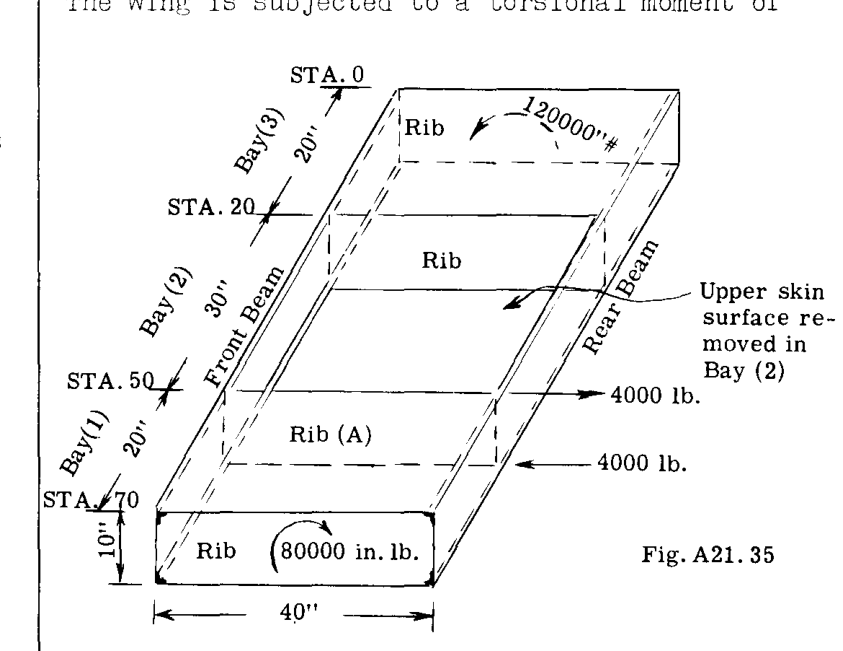

Fig. A21.35

### 解法：

セル壁上の作用せん断流は、リブ (A) の両側にある翼の2つの断面について求められる。

ベイ (1) では、ねじりモーメント $M$ は $80000\text{ in.lb.}$ である。したがって、ベイ (1) における翼の断面上の作用せん断流は次のように等しくなる。

$$q = \frac{M}{2A} = \frac{80000}{2 \times 10 \times 40} = 100\text{ lb./in.}$$

このせん断流システムは、リブ (A) の自由体力図である Fig. A21.36 に示されている。ベイ (2) では、上部外板が除去されているため、ねじりモーメントは前後の垂直ウェブによって負担されなければならない。なぜなら、下部外板のせん断流はバランスを取ることができないからである。

ベイ (2) のねじりモーメントは、

$$M = 80000 + 4000 \times 10 = 120000\text{ in.lb.}$$

したがって、各垂直ウェブ上の全せん断荷重は $120000/40 = 3000\text{ lb.}$ となり、これは各ウェブに $q' = 3000/10 = 300\text{ lb./in.}$ のせん断流を与える。この作用せん断は、Fig. A21.36 のリブ (A) の自由体力図に示されている。リブの左端では、100 のせん断流が上向きに作用し、もう一方の側では 300 のせん断流が下向きに作用しているため、リブのウェブはその差、すなわち 200 の下向きの作用を引き受けなければならない。リブの右端では、リブウェブ上の荷重は $200\text{ lb./in.}$ 上向きである。リブの上部および下部フランジ上の荷重は、明らかに $100\text{ lb./in.}$ である。Fig. A21.37 は、ベイ (1) のねじりと外部偶力がベイ (2) の断面に伝達されるときに、リブ境界に作用する荷重を示している。

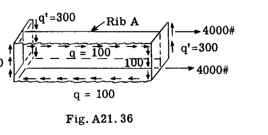

Fig. A21.36

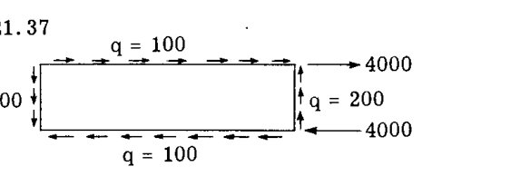

Fig. A21.37

### ベイ (2) の梁の差動曲げによる追加の影響

ベイ (1) のねじりと外部偶力は、中央のベイ (2) の前後の梁に偶力として振り分けられ、前述の計算通り、各梁の全せん断荷重は $3000\text{ lb.}$ となる。これらの梁せん断荷重はベイ (3) に伝達されなければならず、したがってベイ (2) の梁の曲げを引き起こす。各梁は両端で比較的剛なボックス構造、すなわちベイ (1) と (3) に取り付けられているため、梁は端部が回転せずに曲がる傾向がある。これらの端部ボックス構造のたわみを無視すると、梁は端部回転なしで曲がる、すなわち両端固定であると仮定できる。Fig. A21.38a は、端部回転がないという仮定の下でのベイ (2) の前方梁のたわみを示している。梁の弾性曲線はスパン中央にたわみ点（変曲点）を持つ。Fig. A21.38b, c は梁の曲げモーメント図およびせん断力図を示している。

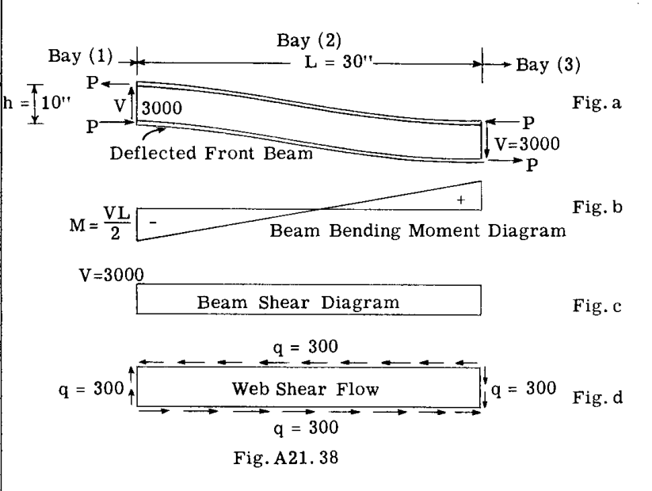

Fig. A21.38

端部モーメントは $M = VL/2 = 3000 \times 30/2 = 45000\text{ in.lb.}$ である。梁のフランジが全曲げ抵抗を発達させると仮定すると、梁端部における梁フランジ荷重は $P = 45000/10 = 4500\text{ lb.}$ となる（Fig. a 参照）。

後方梁のたわみは Fig. a の逆になり、したがってすべての力も逆になる。

Fig. A21.39 は、ベイ (2) の梁の曲げによるフランジ荷重が作用する自由体としての翼のベイ (1) を示している。ベイ (2) からのこれらの内部フランジ力は、隣接するベイ (1) の翼構造内の内部応力によって平衡状態に保持されなければならない。

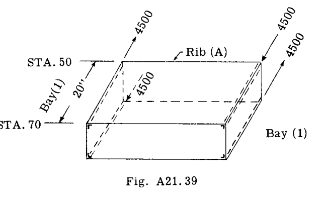

Fig. A21.39

サン・ブナンの有名な力学原理によると、このような内部力システムから生じる応力は、力から離れた場所では無視できるようになる。切り欠きの場合、この距離は通常、切り欠きの幅にほぼ等しいか、一般に隣接する翼ベイの幅に等しいと仮定される。したがって、Fig. A21.39 において、それぞれ $4500\text{ lbs.}$ のフランジ荷重は、20 インチの距離にわたって均一な割合で散逸されると仮定される。したがって、各ストリンガー荷重によって生じるせん断流（ベイ (1) のストリンガーにおける1インチあたりの軸荷重の変化に等しい）は、 $4500/20 = 225\text{ lb.}$ に等しくなる。

Fig. A21.40 は、各フランジ部材に $\Delta P$ 荷重が作用する、翼ベイ (1) から切り取られた幅 1 インチのセグメントを示している。断面上のせん断流を求めるために、まず前方ウェブがカットされていると仮定し、したがって、カット面からの静的せん断流 $q_s = \Sigma\Delta P$ は、カット面で $q_s$ がゼロとなる。Fig. A21.40 はこの静的せん断流を示している。

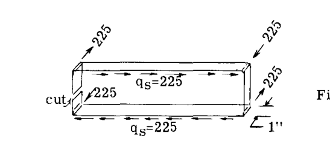

Fig. A21.40

断面の平衡のために、断面の平面内における力のモーメントはゼロに等しくなければならない。 $q_s$ 力システムの左下隅のまわりのモーメントを取ると、

$$M = 225 \times 40 \times 10 = 90000\text{ in.lb.}$$

平衡のためには、 $-90000$ のモーメントが必要である。したがって、 $-90000$ のモーメントを発生させるために、一定のせん断流システム $q$ を追加しなければならない。したがって、

$$q = \frac{M}{2A} = \frac{-90000}{2 \times 10 \times 40} = -112.5\text{ lb./in.}$$

このせん断流を Fig. A21.40 の $q_s$ のせん断流に加えると、Fig. A21.41 に示す最終値が得られる。このせん断流システムは、ベイ (2) の梁の差動曲げによってベイ (1) の断面に発生する応力システムを表している。

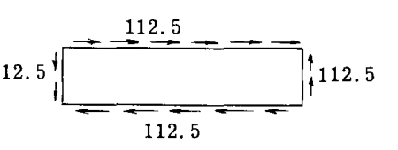

Fig. A21.41

したがって、このせん断流システムは、ベイ (1) の端部で終端しなければならないため、リブ (A) によって抵抗されなければならない。したがって、Fig. A21.41 のせん断流は、リブ (A) に作用する境界荷重であり、これらを Fig. A21.37 のリブ荷重に加えて、Fig. A21.42 の最終的なリブ荷重を得る必要がある。

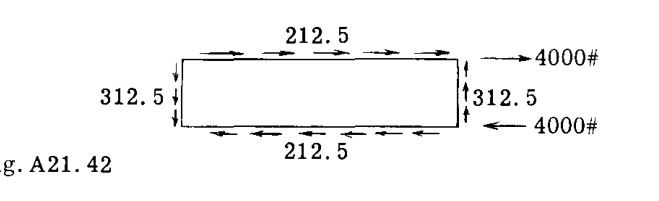

Fig. A21.42

最終的なリブ荷重が分かれば、前述のようにリブのフランジおよびウェブ応力を求めることができる。

## A21.9 例題：曲げ荷重とねじり荷重を受ける切り欠きのある翼

Fig. A21.43 は、4本のストリンガーからなる単一セル片持ち梁の一部を示しており、これは4つのリブによって形成された3つのベイで構成されている。構造物への荷重は、示されているようにベイ (1) の端部に加えられる荷重からなる。コーナーのストリンガー $a, b, c, d$ の断面積は、各ストリンガーの隣に ( ) で示されている。

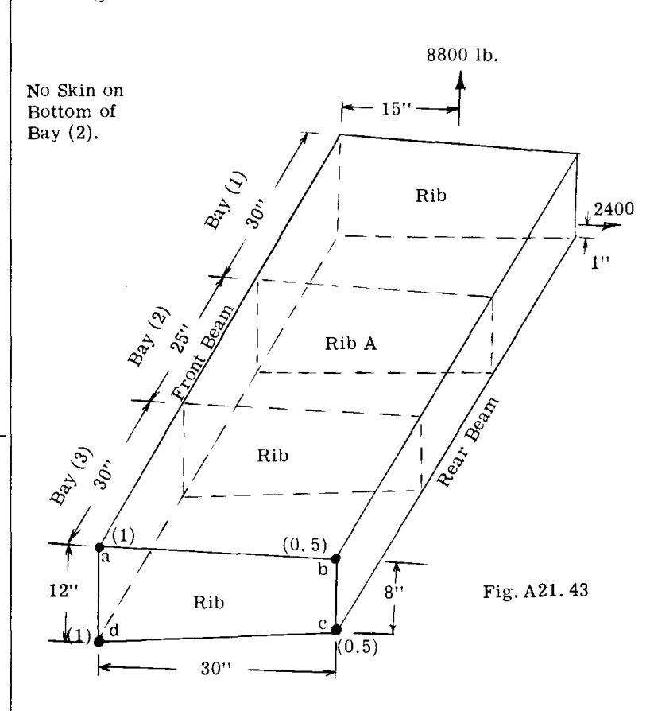

Fig. A21.43

### 解法 No.1

この解法では、ベイ (2) 上の真のねじりモーメントを得るために、ベイ (2) のせん断中心位置を利用する。このねじりモーメントが分かれば、手順は翼のねじりのみを含む前の例題と同様になる。

まず、翼ベイ (1) におけるせん断流を計算する。Fig. A21.44 はその断面を示している。

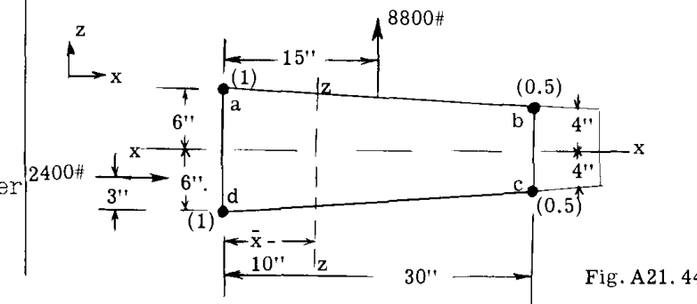

Fig. A21.44

せん断流の計算には断面二次モーメントが必要である。

$$I_x = (1 \times 6^2 \times 2) + (0.5 \times 4^2 \times 2) = 88\text{ in.}^4$$

$$\bar{x} = \Sigma Ax / \Sigma A = (1 \times 30)/3 = 10\text{ in.}$$

$$I_z = (2 \times 10^2) + (1 \times 20^2) = 600\text{ in.}^4$$

$$V_z = 8800\text{ lb.}, V_x = 2400\text{ lb.}$$

$$q_y = -\frac{V_z}{I_x}\Sigma zA - \frac{V_x}{I_z}\Sigma xA\text{、代入すると、}$$

$$q_y = -100\Sigma zA - 4\Sigma xA \quad \text{--- (a)}$$

セル上の任意の点におけるせん断流は未知であるため、前方ウェブ (ad) がカットされている、すなわちせん断を伝達しないと仮定する。

$$q_{dc} = -100(-6)(1) - 4(-10)(1) = 640\text{ lb./in.}$$

$$q_{cb} = 640 - 100(-4)(0.5) - 4(20)0.5 = 800$$

$$q_{ba} = 800 - 100(4)(0.5) - 4(20)0.5 = 560$$

Fig. A21.45 は、これらの静的せん断流を示している。

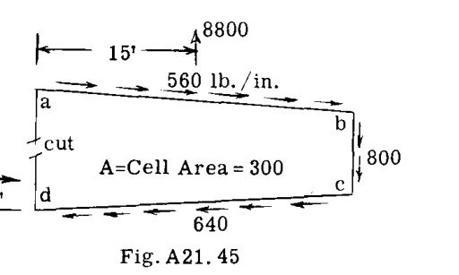

Fig. A21.45

このせん断流に、 $\Sigma M = 0$ とするための一定のせん断流を加えなければならない。点 (d) まわりのモーメントを取る。

$$\Sigma M_d = -8800 \times 15 + 2400 \times 3 + 560 \times 30 \times 12 + 800 \times 8 \times 30 = 268800\text{ in. lb.、または } -268800$$

が平衡のために必要である。したがって、必要な一定のせん断流は $q = -M/2A = -268800/2 \times 300 = -448$ である。このせん断流を Fig. A21.45 のせん断流に加えると、Fig. A21.46 のせん断流が得られる。

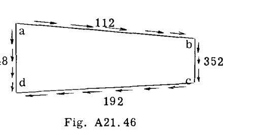

Fig. A21.46

このせん断流システムは、ベイ (2) の下部外板が除去されない場合の、3つのベイすべてに対するせん断流システムとなる。ベイ (2) の下部外板を除去すると、Fig. A21.46 のこれらのせん断流が修正される。

したがって、下部外板が除去された真の状態のベイ (2) を考慮する。Fig. A21.47 はベイ (2) の断面を示している。

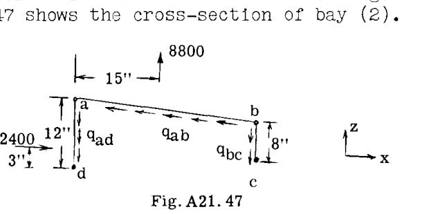

Fig. A21.47

3つのせん断流は静力学によって決定できる。

$$\Sigma F_x = 2400 - 30 q_{ab} = 0\text{、これより } q_{ab} = 80$$

$$\Sigma M_d = 2400 \times 3 - 8800 \times 15 - 80 \times 30 \times 12 + q_{bc}(8 \times 30) = 0\text{、これより } q_{bc} = 640$$

$$\Sigma F_z = 8800 - 8 \times 640 + 2 \times 80 - 12 q_{ad} = 0\text{、これより } q_{ad} = 320$$

Fig. A21.48 はその結果を示している。このせん断流システムは、ベイ (2) における最終的な、すなわち真のせん断流である。

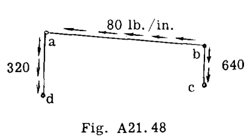

Fig. A21.48

ベイ (2) にチャンネル型または開断面の翼があるため、このベイにおける任意のねじりモーメントは、前方および後方の梁の差動曲げによって伝達されなければならない。ベイ (2) のねじりモーメントを得るためには、せん断中心の位置を知る必要がある。

せん断中心の水平位置：

$V_z$ 荷重 $8800\text{ lb.}$ の下で、ねじれなしで断面が図心 X 軸まわりに曲がると仮定する。

$$q = -\frac{V_z}{I_x}\Sigma zA\text{、または } q = -100\Sigma zA$$

$$q_{cb} = -100(-4)(0.5) = 200$$

$$q_{ba} = 200 - 100(4)(0.5) = 0$$

$$q_{ad} = 0 - 100(6)(1) = -600$$

Fig. A21.49 は、ねじれなしの x-x まわりの曲げに対するせん断流の結果を示している。このせん断流システムの合力の作用線が、せん断中心の水平位置を定める。

$$\bar{x} = (200 \times 8 \times 30)/8800 = 5.45\text{ in.}$$

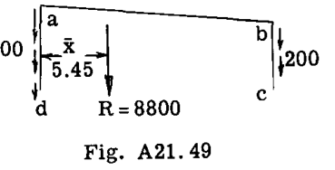

Fig. A21.49

せん断中心の垂直位置：

$V_x = 2400\text{ lb.}$ の荷重の下で、ねじれなしで断面が図心 $z$ 軸まわりに曲がると仮定する。

$$q = -\frac{V_x}{I_z}\Sigma xA = -4\Sigma xA$$

$$q_{cb} = -4 \times 20 \times 0.5 = -40\text{ lb./in.}$$

$$q_{ba} = -40 - 4 \times 20 \times 0.5 = -80$$

$$q_{ad} = -80 - 4(-10)1 = -40$$

Fig. A21.50 はせん断流の結果を示している。

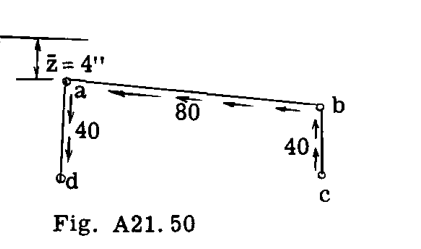

Fig. A21.50

点 (a) から合力の作用線までの垂直距離 $\bar{z}$ （せん断中心の垂直位置を定める）は、

$$\bar{z} = \Sigma M_a / 2400 = (40 \times 8 \times 30)/2400 = 4\text{ in.}$$

Fig. A21.51 は、せん断中心の位置と外力を示している。翼のベイ (2) のねじりに等しい、せん断中心まわりのモーメントは、

$$M_{s.c.} = -8800 \times 9.55 - 2400 \times 13 = -115240\text{ in.lb.}$$

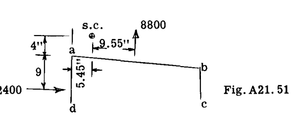

Fig. A21.51

このねじりモーメントは、前方および後方の梁によって抵抗されなければならない。したがって、各梁のせん断荷重 $= 115240/30 = 3841 \text{ lb.}$ である。

ねじりを含む前の例題と同様に、ベイ (2) の梁は端部の回転なしに曲がる、言い換えれば、ベイの中央での曲げモーメントはゼロであると仮定する。ベイ (2) の梁の差動曲げによる、ベイ (1) の点 a, b, c, d におけるフランジ荷重は、梁のせん断力にベイ (2) のスパンの半分を乗じ、梁の高さで除したものに等しい。

前方梁の場合、 $P = 3841 \times 12.5/12 = 4000\text{ lb.}$ である。

後方梁の場合、 $P = 3841 \times 12.5/8 = 6000\text{ lb.}$ である。

Fig. A21.52 は、これらのフランジ荷重がベイ (1) に作用している状態を示している。これらの荷重は散逸される。

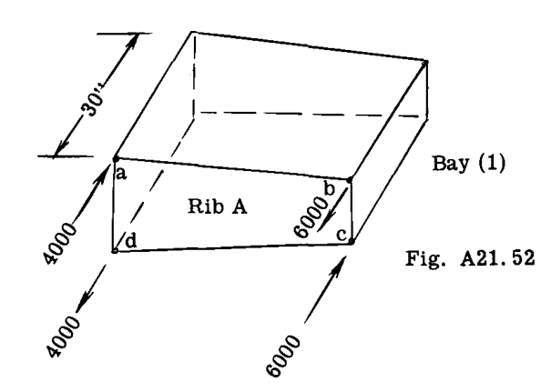

Fig. A21.52

ベイ (1) において 30 インチの距離にわたって均一に散逸され、これらのフランジ荷重によって生じる 1 インチあたりのせん断流は $\Delta P = P/30$ に等しくなる。これより、

$$\Delta P_a = \Delta P_d = 4000/30 = 133.3\text{、および }\Delta P_b = \Delta P_c = 6000/30 = 200\text{ lb.}$$

Fig. A21.53 は、これらの $\Delta P$ 荷重が作用する、翼ベイ (1) の幅 1 インチの要素を示している。前方ウェブがカットされていると仮定したせん断流 $q$ は $\Sigma\Delta P$ に等しい。 $\Sigma\Delta P$ に等しい、結果として得られる静的せん断流は Fig. A21.53 に示されている。

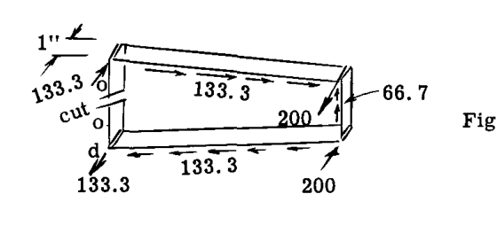

Fig. A21.53

点 (d) まわりのこのせん断流システムのモーメントは、

$$M = 133.33 \times 30 \times 12 - 66.7 \times 8 \times 30 = 31980$$

である。 $\Sigma M = 0$ のためには、一定のせん断流 $q = -31980/2 \times 300 = -53.3\text{ lb./in.}$ が必要である。この一定のせん断流を Fig. A21.53 のせん断流に加えると、Fig. A21.54 のせん断流システムが得られる。これらの結果は、ベイ (1) への影響を表している。

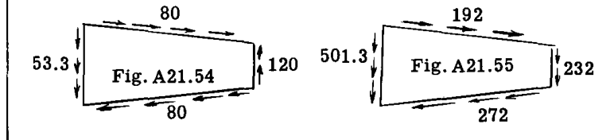

Fig. A21.54

ベイ (2) の下部外板を取り除いた影響。Fig. A21.54 のせん断流を Fig. A21.46 のせん断流に加えると、Fig. A21.55 に示すように、ベイ (1) における最終的なせん断流が得られる。

### リブ (A) の境界荷重

リブ (A) の境界荷重は、ベイ (1) と (2) のせん断流の差に等しくなる。Fig. A21.56 は、Fig. A21.55 および A21.48 から得られたせん断流を伴うリブ (A) の自由体力図を示している。

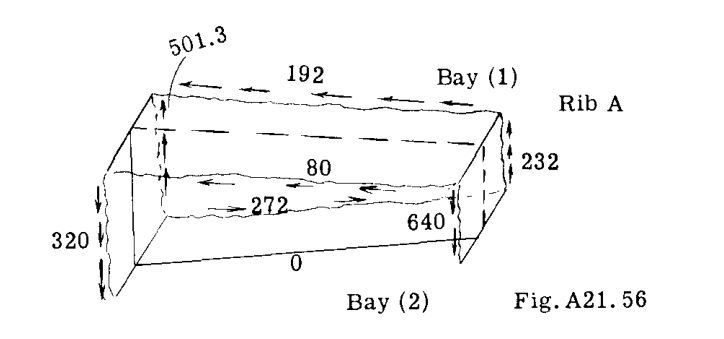

Fig. A21.56

リブに作用する結果としての境界力は、リブの各側におけるせん断流の代数和に等しく、これは Fig. A21.57 の値を与える。

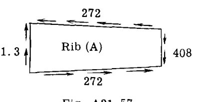

Fig. A21.57

リブの境界荷重が分かれば、本章で前述したようにリブの応力を求めることができる。

### 解法 No.2

この解法は、まず、中央のベイ (2) で下部外板が除去されていないと仮定して、すべてのベイにおけるせん断流を求める。これにより、下部外板にせん断流が生じる。しかし、ベイ (2) の外板は実際には除去されているため、下部外板に生じたせん断流をなくすために、下部外板の境界線に沿ってベイ (2) に一連の修正せん断流を作用させなければならない。この問題は、下部外板が除去されていない場合にベイ (1) および (2) について求められたせん断流に対する、これらの修正せん断流の影響を求めることからなる。

最初のステップは、ベイ (2) の下部外板が除去されていないと仮定して、すべてのベイにおけるせん断流を求めることである。計算は解法 (1) とまったく同じであり、すべてのベイにおけるせん断流は Fig. A21.46 のものとなる。Fig. A21.46 の下部外板には、示されているような向きで 192 のせん断流がある。この外板は存在しないため、このせん断流を反転させ、ベイ断面の他の3つの側における抵抗せん断流を求める。Fig. A21.58 は、3つの未知のせん断流 $q_{ab}, q_{bc}, q_{ad}$ を持つ断面を示している。

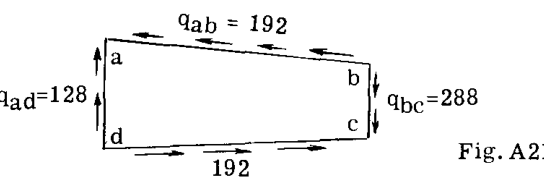

Fig. A21.58

$q_{ab}$ を求めるには、 $\Sigma F_x = 0$ を使用する。

$$192 \times 30 - 30 q_{ab} = 0\text{、これより } q_{ab} = 192$$

$$\Sigma M_d = -30 \times 192 \times 12 + 8 q_{bc} \times 30 = 0\text{、これより } q_{bc} = 288$$

$$\Sigma F_z = 4 \times 192 - 8 \times 288 + 12 q_{ad} = 0\text{、これより } q_{ad} = 128$$

Fig. A21.58 のせん断流を Fig. A21.46 のせん断流に加えると、Fig. A21.59 に示すように、ベイ (2) における最終的なせん断流が得られる。

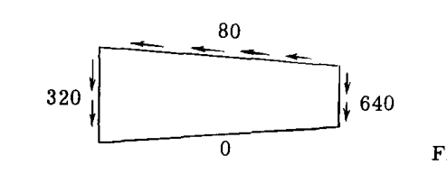

Fig. A21.59

これらの結果は、解法 (1) で得られた Fig. A21.48 の結果と一致する。

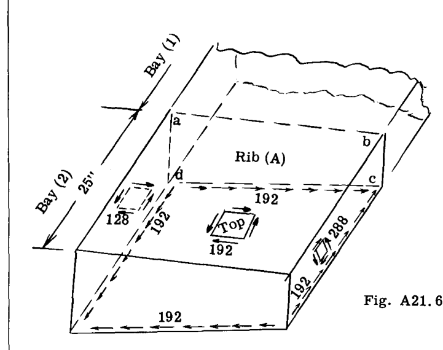

Fig. A21.60

Fig. A21.60 は、ベイ (2) に加えられた Fig. A21.58 の修正せん断流を示している。下部外板上には、切り欠きの境界に修正せん断流が示されている。これらのせん断流は、ベイ (2) の前方および後方の梁の差動曲げを引き起こす。梁の端部が回転しないと仮定すると、曲げモーメントはベイの中央でゼロになり、したがって、ベイ (1) の点 a, b, c, d におけるフランジ荷重は、フランジの各側におけるせん断流の代数和に、ベイ (2) のスパンの半分、すなわち 12.5 インチを乗じたものに等しくなる。したがって、Fig. A21.60 から、

$$P_a = (192 + 128) 12.5 = 4000\text{ lb.（圧縮）}$$

$$P_b = (288 + 192) 12.5 = 6000\text{ lb.（引張）}$$

$$P_c = (288 + 192) 12.5 = 6000\text{ lb.（圧縮）}$$

$$P_d = (128 + 192) 12.5 = 4000\text{ lb.（引張）}$$

Fig. A21.52 を参照すると、上記の P 値は解法 (1) によって得られた P 値と同じであることがわかる。したがって、解法 (2) の残りの部分は解法 (1) と同一になるため、ここでは計算を繰り返さない。

## A21.10 胴体フレーム

胴体のフレームは、翼構造におけるリブと同じ目的を果たす。リブは通常、梁またはトラス構造であり、静力学によってかなり正確に応力解析を行うことができる。しかし、胴体フレームは閉リング型の構造であるため、内部応力に対して静的に不確定である。フレームに作用する荷重が分かれば、第 A8、A9、A10、A11 章で扱う弾性理論を適用して内部応力を求めることができる。窓やドアなどによる胴体構造の不連続性に起因する胴体フレーム上の荷重は、翼リブについて前述した手順によってほぼ決定することができる。

第 A15 章の 32 ページの写真は、ダグラス DC-8 旅客機のフレーム構造の一部を示している。胴体構造の他の写真は第 A20 章に示されている。Photo A21.4 および 5 は、典型的なフレームの構造と配置を示している。

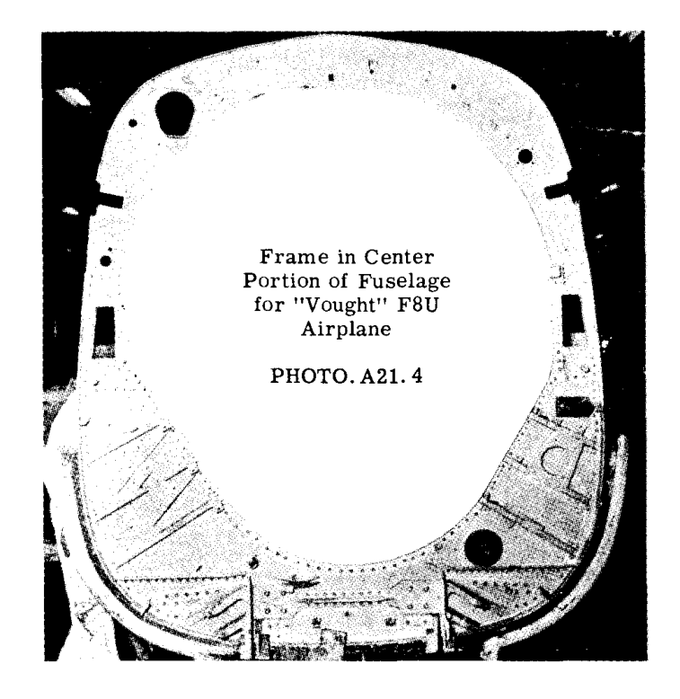

PHOTO. A21.4

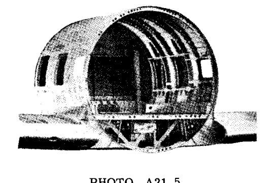

PHOTO. A21.5

## A21.11 胴体フレーム上の支持境界力

外部集中荷重が適切なフィッティングまたは接続を介して胴体フレームに加えられると、フレームは、通常、フレームを外板に固定するリベットによってフレーム境界に伝達される、反力としての胴体外板の力によって平衡状態に保持される。胴体シェルは通常、梁理論によって応力解析されるため、支持外板力の分布を同じ理論によって決定することは一貫している。

## A21.12 フレーム境界支持力の計算

### 例題 1

Fig. A21.61 は、円形胴体の断面を示している。それぞれ $2000\text{ lb.}$ の2つの集中荷重が、示された点で胴体フレームに加えられている。問題は、2つの外部印加荷重とバランスをとる、胴体外板における反らせん断流力を決定することである。この胴体断面は、中型胴体の後部と見なすことができ、荷重は水平尾翼表面上の空気荷重によるものである。数値計算を簡略化するため、胴体ストリンガーの配置は対称であると仮定されている。

### 解法：

この解法では、胴体外板の抵抗力は一般的な梁理論に従って変化すると仮定される。 $y$ 軸まわりの曲げに対する一般的な曲げせん断流方程式は、

$$q = -\frac{V_z}{I_y}\Sigma zA\text{、ここで } V_z = 4000\text{ lb.}$$

胴体断面の断面二次モーメント $I_y$ が必要である。この簡略化された例では、各ストリンガーの面積とその有効外板を合わせた面積を $.15\text{ sq.in.}$ とする。学生は当然、第 A19 章と A20 章を学んだ後、有効な面積を圧縮側で使用し、胴体の引張側の外板は完全に有効であることを理解すべきである。これらの事実は、有効断面を $y$ 軸に対して非対称にする傾向がある。この例題の唯一の目的は、フレーム荷重がどのようにバランスしているかを示すことであるため、断面は対称であると仮定され、これにより必要な計算量が大幅に削減される。

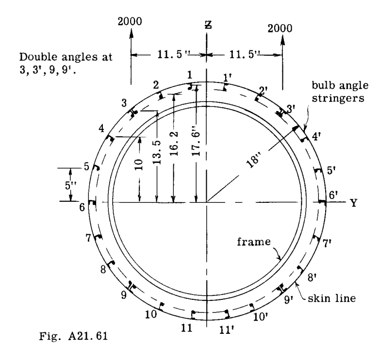

Fig. A21.61

簡略化された仮定の下で、中立軸である $y$ 軸まわりの胴体断面の断面二次モーメント。

$$I_y = .15 (17.6^2 + 16.2^2 + 13.5^2 + 13.5^2 + 10^2 + 5^2) 4 = 637\text{ in.}^4$$

有効断面および外部荷重の対称性により、 $z$ 軸上、またはストリンガー 1 と $1'$ 、および 11 または $11'$ の間の胴体外板におけるせん断流はゼロになる。したがって、ストリンガー (1) から始めて、 $4000\text{ lb.}$ の外力に抵抗する外板内のせん断流は、断面の円周に沿って次のように書くことができる。

$$q = -\frac{V_z}{I_y}\Sigma zA = -\frac{4000}{637}\Sigma zA = -6.275\Sigma zA$$

$$q_{1-2} = -6.275 \times .15 \times 17.6 = -16.57\text{ lb./in.}$$

$$q_{2-3} = -16.57 - 6.275 \times .15 \times 16.2 = -31.82$$

$$q_{3-4} = -31.82 - 6.275 \times .30 \times 13.5 = -57.22$$

$$q_{4-5} = -57.22 - 6.275 \times .15 \times 10 = -66.62$$

$$q_{5-6} = -66.62 - 6.275 \times .15 \times 5 = -71.32$$

有効断面の対称性により、せん断流は $y$ 軸に関して対称である。

上記作業のチェックとして、各外板パネル上のせん断流の $z$ 成分の総和は、 $4000\text{ lb.}$ の外力に等しくなければならない。

パネル間のストリンガーの垂直投影長さ、または、

$$\Sigma F_z = [1.4 \times 16.57 + 2.7 \times 31.82 + 3.5 \times 57.22 + 5 \times 66.62 + 5 \times 71.32] 4 = 4000\text{ lb.}$$

（チェック完了）

Fig. A21.62 は、バランスのとれた荷重システムを持つフレームを示している。内部応力は、第 A8 章から A11 章の方法によって求めることができる。

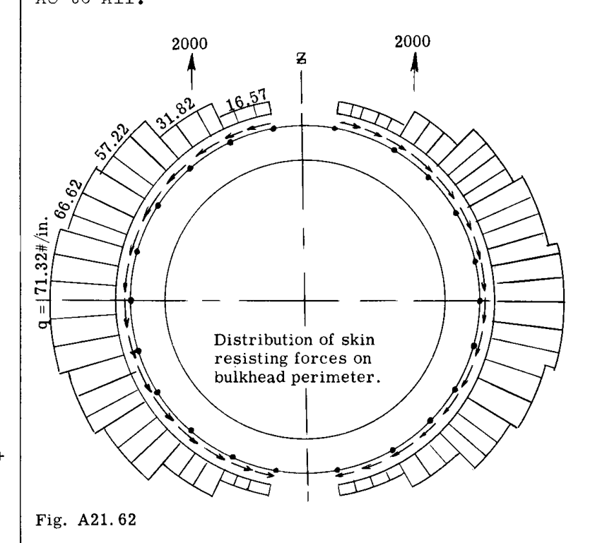

Fig. A21.62

### 例題 2：非対称垂直荷重

飛行および着陸の特定の状態において、非対称な集中荷重が胴体またはハル構造に加えられる。たとえば、Fig. A21.63 は、例題 1 で使用したものと同じ断面とフレームを示している。水平尾翼上の非対称荷重により、尾翼から胴体への反力は図に示すようになる。 $z$ 方向の全荷重は依然として $4000\text{ lb.}$ であるが、荷重は $z$ 軸に関して対称ではない。解析のために、荷重を断面の図心（c.g.）に伝達されたものとして考慮する（Fig. A21.64 に示すように）。

図心まわりの2つの荷重のモーメントは、 $1500 \times 11.5 - 2500 \times 11.5 = -11500\text{ in.lb.}$ である。せん断荷重 $V_z = 4000$ は、Fig. A21.62 と同じせん断流パターンを発生させる。 $-11500$ のモーメントのバランスをとるために、フレームのまわりに一定のせん断流 $q_1$ が必要である。

$$q = \frac{M}{2A} = \frac{11500}{2 \times \pi \times 18^2} = 5.65\text{ lb./in.}$$

（ $A$ = 胴体断面積）

この一定の力システムを Fig. A21.62 のシステムに加えると、Fig. A21.65 に示すように、フレーム上の最終的な境界支持力が得られる。フレームの弾性応力解析を進めることができる。

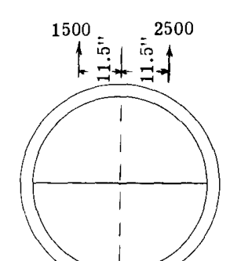

Fig. A21.63

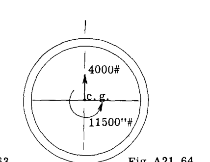

Fig. A21.64

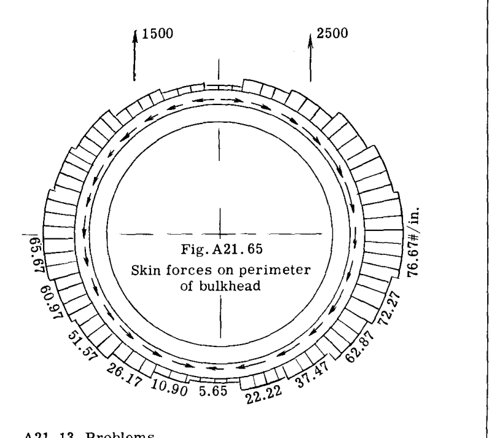

Fig. A21.65